# Lab 6

Brenna Kelly

10/21/2021

### Exercise 1

**Instructions:** The file *gapminderData5.csv* contains a subset of the GapMinder dataset for 142 countries over 12 time steps (every 5 years between 1952 and 2007).

- Read the data in amd use the tapply() function to estimate the mean life expectancy by country (tapply(gap$lifeExp, gap$country, mean))

```r
gap <- read.csv("gapminderData5.csv")

m_le <- tapply(gap$lifeExp, gap$country, mean)
head(m_le)
```

```
## Afghanistan     Albania     Algeria      Angola   Argentina   Australia
##    37.47883    68.43292    59.03017    37.88350    69.06042    74.66292
```

- Make a scatter plot of lifeExp vs. year for all countries

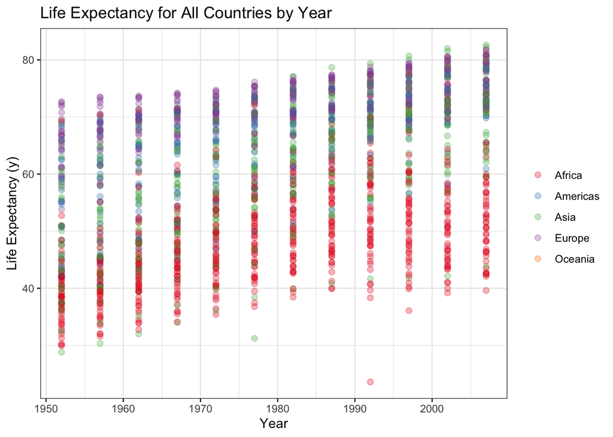

```r
plt_lifeExp_year <- ggplot(gap, aes(year, lifeExp, color=continent)) +
  geom_point(alpha = 0.3, cex = 2) +
  labs(y = "Life Expectancy (y)", x = "Year") +
  ggtitle("Life Expectancy for All Countries by Year") +
  theme_bw() +
  theme(legend.title = element_blank()) +
  scale_colour_brewer(palette = "Set1")
plt_lifeExp_year
```

- Here’s some example code to make a line plot of lifeExp vs. year for the United States. Use this to make plots for two countries.

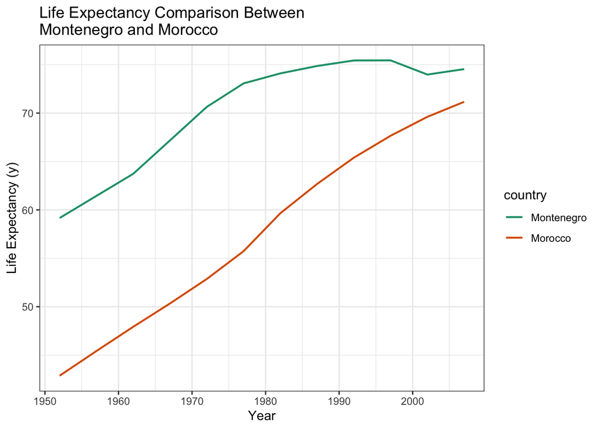

```r
gap_subset <- gap[which(gap$country == "Montenegro" | gap$country == "Morocco"),]

plt_line <- ggplot(gap_subset, aes(x = year, y = lifeExp,
                       colour = country)) +
  geom_line(size = 0.75) +
  theme_bw() +
  labs(x = "Year", y = "Life Expectancy (y)") +
  ggtitle("Life Expectancy Comparison Between \nMontenegro and Morocco") +
  scale_colour_brewer(palette = "Dark2")

plt_line
```

- Use these data to build a simple linear model (lm()) of lifeExp as a function of year. Before making the model, center the year variable by subtracting 1952 from all values (0 now represents the year 1952)
  - Report the coefficients, their significance and a brief explanation of what each one means
  - Give the F-statistic and associated p-value

```r
gap$year_c_s <- (gap$year - 1952) / 10

summary(life_lm <- lm(lifeExp ~ year_c_s,
               data = gap))
```

```
##
## Call:
## lm(formula = lifeExp ~ year_c_s, data = gap)
##
## Residuals:
##     Min      1Q  Median      3Q     Max
## -39.949  -9.651   1.697  10.335  22.158
##
## Coefficients:
##             Estimate Std. Error t value Pr(>|t|)
## (Intercept)  50.5121     0.5300   95.31   <2e-16 ***
## year_c_s      3.2590     0.1632   19.96   <2e-16 ***
## ---
## Signif. codes:  0 '***' 0.001 '**' 0.01 '*' 0.05 '.' 0.1 ' ' 1
##
## Residual standard error: 11.63 on 1702 degrees of freedom
## Multiple R-squared:  0.1898, Adjusted R-squared:  0.1893
## F-statistic: 398.6 on 1 and 1702 DF,  p-value: < 2.2e-16
```

**Answer:** The intercept is 50.5121 (p<2e-16), meaning that in the year 1952 (t = 0), the expected value for life expectancy globally was 50.5 years or so. The coefficient estimate for `year` is 3.259 (p < 2e-16) — every decade after 1952, the life expectancy increased by about 3 years and 3 months. Our F-statistic is 398.6 (p < 2.2e-16).

- Now build a random intercept model using the lme() function, using country as the grouping variable for the random effect (the random effect will look something like random = ~ 1 | country). Report:
  - The fixed effect coefficients and associated p-values (see under Fixed effects in the summary() output)
  - The reported standard deviation for the two random effects ((Intercept) and Residual)

```r
summary(life_lme <- lme(lifeExp ~ year_c_s,
                random = ~ 1 | country,
                data = gap))
```

```
## Linear mixed-effects model fit by REML
##  Data: gap
##        AIC      BIC    logLik
##   9869.658 9891.417 -4930.829
##
## Random effects:
##  Formula: ~1 | country
##         (Intercept) Residual
## StdDev:    11.09716 3.584196
##
## Fixed effects: lifeExp ~ year_c_s
##                Value Std.Error   DF  t-value p-value
## (Intercept) 50.51208 0.9454671 1561 53.42553       0
## year_c_s     3.25904 0.0503048 1561 64.78581       0
##  Correlation:
##          (Intr)
## year_c_s -0.146
##
## Standardized Within-Group Residuals:
##        Min         Q1        Med         Q3        Max
## -6.1691513 -0.4910339  0.1216455  0.6030002  2.4194109
##
## Number of Observations: 1704
## Number of Groups: 142
```

**Answer:** The fixed effect coefficients are: Intercept: 50.512 (p = 0), Year: 3.259 (p = 0). The standard deviations are 11.097 (Intercept) and 3.584 (Residual).

- Calculate the ICC for the random intercept in this model. You will need to use VarCorr() to find the variance of the intercept and residual term (quick reminder, the intercept ICC is the variance of the intercept, divided by the sum of variances). Given the value you obtain, does this support the use of a random intercept model?

```r
icc <- VarCorr(life_lme)
icc
```

```
## country = pdLogChol(1)
##             Variance  StdDev
## (Intercept) 123.14688 11.097156
## Residual     12.84646  3.584196
```

```r
123.14688 + 12.84646 #Total Variance in the Model: 135.993
```

```
## [1] 135.9933
```

```r
123.14688 / 135.993 # Proportion of Variation Due to Slope (ICC): 0.9055
```

```
## [1] 0.9055384
```

```r
12.84646 + 3.584196 # Residual Variation: 16.43
```

```
## [1] 16.43066
```

**Answer:** With an ICC of 90.55%, there is support for using the random intercept model.

- Now build a third model with a random intercept and slope. The random effect will look something like random = ~ year2 | country. Show the output of summary() for this model.

```r
summary(life_rand <- lme(lifeExp ~ year_c_s,
                random = ~ year_c_s | country,
                data = gap))
```

```
## Linear mixed-effects model fit by REML
##  Data: gap
##        AIC     BIC    logLik
##   8742.672 8775.31 -4365.336
##
## Random effects:
##  Formula: ~year_c_s | country
##  Structure: General positive-definite, Log-Cholesky parametrization
##             StdDev    Corr
## (Intercept) 12.302796 (Intr)
## year_c_s     1.582867 -0.434
## Residual     2.180792
##
## Fixed effects: lifeExp ~ year_c_s
##                Value Std.Error   DF  t-value p-value
## (Intercept) 50.51208 1.0371995 1561 48.70045       0
## year_c_s     3.25904 0.1363121 1561 23.90865       0
##  Correlation:
##          (Intr)
## year_c_s -0.439
##
## Standardized Within-Group Residuals:
##         Min          Q1         Med          Q3         Max
## -8.08192929 -0.34891405  0.02690066  0.39742349  4.67388085
##
## Number of Observations: 1704
## Number of Groups: 142
```

- Finally, use the AIC() function to get the AIC for the three models (linear, random intercept and random intercept and slope). As a reminder: the AIC is a good criterion of the quality of the model, as it penalizes when extra predictors (overfitting). The models with the lowest AIC values are best. Which of your models is best?

```r
AIC(life_lm, life_lme, life_rand)
```

```
##           df       AIC
## life_lm    3 13201.732
## life_lme   4  9869.658
## life_rand  6  8742.672
```

**Answer:** With an AIC of 8742.672, the model with the best fit is the model with a random intercept and slope. This makes intuitive sense, since there was a lot of variation in life expectancy between countries in 1952 — we would expect the intercept to vary by country.

```r
x <- data.frame(life_rand[["coefficients"]][["random"]][["country"]])
max(x$year_c_s)
```

```
## [1] 4.236716
```

```r
min(x$year_c_s)
```

```
## [1] -3.972096
```

```r
max(life_lme[["coefficients"]][["fixed"]][["year_c_s"]])
```

```
## [1] 3.259038
```

```r
min(life_lme[["coefficients"]][["fixed"]][["year_c_s"]])
```

```
## [1] 3.259038
```

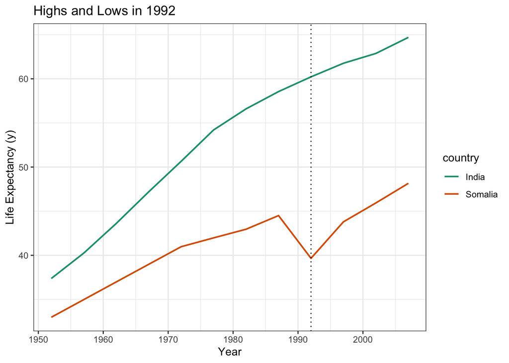

```r
gap_subset_2 <- gap[which(gap$country == "India" | gap$country == "Somalia"),]
gap_subset_3 <- gap[which(gap$country == "Zimbabwe" | gap$country == "Oman"),]

ggplot(gap_subset_2, aes(x = year, y = lifeExp,
                       colour = country)) +
  geom_line(size = 0.75) +
  theme_bw() +
  labs(x = "Year", y = "Life Expectancy (y)") +
  ggtitle("Highs and Lows in 1992") +
  scale_colour_brewer(palette = "Dark2") +
  geom_vline(xintercept = c(1992, 1992), linetype = "dotted")
```

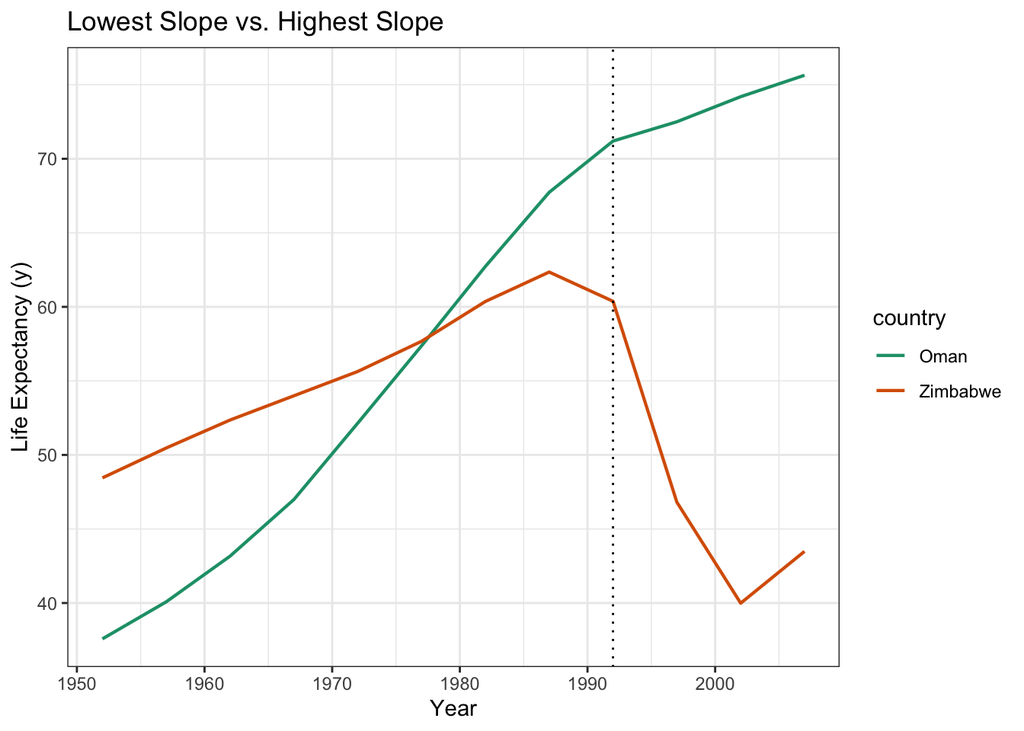

```r
ggplot(gap_subset_3, aes(x = year, y = lifeExp,
                       colour = country)) +
  geom_line(size = 0.75) +
  theme_bw() +
  labs(x = "Year", y = "Life Expectancy (y)") +
  ggtitle("Lowest Slope vs. Highest Slope") +
  scale_colour_brewer(palette = "Dark2") +
  geom_vline(xintercept = c(1992, 1992), linetype = "dotted")
```